# 05_taxonomic_assignment_rate

Author

Hugo Maruyama

Published

March 6, 2026

## Introduction

Taxonomic assignment rate is a critical metric for evaluating the performance of sequencing platforms and bioinformatics pipelines. It represents the proportion of sequencing reads that can be confidently assigned to specific taxonomic ranks (e.g., genus or species). In this section, the assignment rates of Illumina MiSeq and Oxford Nanopore Technologies (ONT) platforms are compared across all hierarchical levels.

## Environment Setup

Necessary libraries for data processing and visualization are loaded.

```r
library(tidyverse)
library(knitr)
```

## Data Integration and Refinement

Harmonized datasets are imported and taxonomic nomenclature is standardized. For consistency with previous analysis modules, the species-level labels are refined while maintaining platform-specific naming conventions for unique taxa.

```r
# Load processed data objects from previous modules
illumina_processed <- readRDS("processed_data/illumina_processed.rds")
nanopore_processed <- readRDS("processed_data/nanopore_processed.rds")

# Standardize species-level nomenclature
# Illumina: Combine genus and species
illumina_processed <- illumina_processed %>%
  dplyr::mutate(
    species = dplyr::if_else(
      !is.na(genus) & !is.na(species),
      stringr::str_c(genus, species, sep = " "),
      species
    )
  )

# Nanopore: Combine genus and species with exception for TM7/Patescibacteria
nanopore_processed <- nanopore_processed %>%
  dplyr::mutate(
    species = dplyr::if_else(
      !is.na(genus) & !is.na(species) & !stringr::str_starts(species, "TM7"),
      stringr::str_c(genus, species, sep = " "),
      species
    )
  )
```

## Calculation of Taxonomic Assignment Rates

A function is defined to calculate the percentage of total abundance assigned at each taxonomic level. This metric is computed for each sample and then aggregated by sequencing platform.

```r
#' Calculate Taxonomic Assignment Rates
#'
#' @param processed_df Processed abundance table
#' @param sequencer_label Label for the sequencing platform
#' @return Data frame with assignment rates per sample and level
calculate_assignment_rates <- function(processed_df, sequencer_label) {
  taxa_levels <- c("kingdom", "phylum", "class", "order", "family", "genus", "species")

  # Reshape to long format for calculation
  long_data <- processed_df %>%
    tidyr::pivot_longer(cols = where(is.numeric), names_to = "Sample", values_to = "Abundance")

  # Compute assignment rates per level
  purrr::map_dfr(taxa_levels, function(level) {
    long_data %>%
      dplyr::group_by(Sample) %>%
      dplyr::summarise(
        Assignment_Rate_Percent = sum(Abundance[!is.na(!!rlang::sym(level))]),
        .groups = 'drop'
      ) %>%
      dplyr::mutate(Taxonomic_Level = level)
  }) %>%
    dplyr::mutate(Sequencer = sequencer_label)
}

# Apply the calculation to both platforms
illumina_rates <- calculate_assignment_rates(illumina_processed, "Illumina MiSeq")
nanopore_rates <- calculate_assignment_rates(nanopore_processed, "Oxford Nanopore")

# Combine results for comparative analysis
combined_rates <- dplyr::bind_rows(illumina_rates, nanopore_rates)
```

## Statistical Summary

Assignment rates are summarized by calculating the mean and standard deviation for each taxonomic level and platform.

```r
taxa_levels <- c("kingdom", "phylum", "class", "order", "family", "genus", "species")

assignment_summary <- combined_rates %>%
  dplyr::group_by(Sequencer, Taxonomic_Level) %>%
  dplyr::summarise(
    Mean_Rate = mean(Assignment_Rate_Percent),
    SD_Rate = sd(Assignment_Rate_Percent),
    .groups = 'drop'
  ) %>%
  dplyr::mutate(Taxonomic_Level = factor(Taxonomic_Level, levels = taxa_levels)) %>%
  dplyr::arrange(Taxonomic_Level)

# Display the summary table
kable(assignment_summary, caption = "Mean Taxonomic Assignment Rates (%) by Platform")
```

Mean Taxonomic Assignment Rates (%) by Platform

| Sequencer | Taxonomic_Level | Mean_Rate | SD_Rate |
| --- | --- | --- | --- |
| Illumina MiSeq | kingdom | 100.00225 | 0.0054391 |
| Oxford Nanopore | kingdom | 96.23325 | 1.3797402 |
| Illumina MiSeq | phylum | 99.99925 | 0.0037749 |
| Oxford Nanopore | phylum | 96.23325 | 1.3797402 |
| Illumina MiSeq | class | 99.99925 | 0.0037749 |
| Oxford Nanopore | class | 96.23325 | 1.3797402 |
| Illumina MiSeq | order | 99.97750 | 0.0302600 |
| Oxford Nanopore | order | 96.23325 | 1.3797402 |
| Illumina MiSeq | family | 99.97750 | 0.0302600 |
| Oxford Nanopore | family | 96.23325 | 1.3797402 |
| Illumina MiSeq | genus | 99.97625 | 0.0323561 |
| Oxford Nanopore | genus | 96.23325 | 1.3797402 |
| Illumina MiSeq | species | 70.97300 | 13.6614420 |
| Oxford Nanopore | species | 95.36250 | 1.9233666 |

## Visualization of Assignment Rates

Assignment rates are visualized using a combination of bar charts (means) and individual data points (samples) to highlight both the overall performance and the variance within each platform.

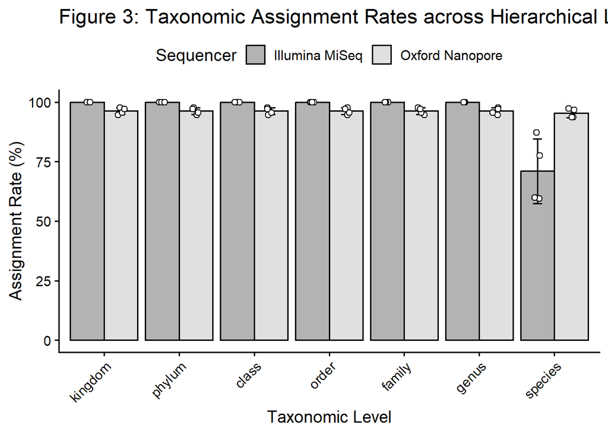

```r
assignment_rate_plot <- assignment_summary %>%
  ggplot(aes(x = Taxonomic_Level, y = Mean_Rate, fill = Sequencer)) +
  # Bar chart for mean values
  geom_bar(stat = "identity", position = position_dodge(), color = "black", alpha = 0.6) +
  # Error bars for standard deviation
  geom_errorbar(
    aes(ymin = Mean_Rate - SD_Rate, ymax = Mean_Rate + SD_Rate),
    width = 0.25,
    position = position_dodge(0.9)
  ) +
  # Individual sample data points
  geom_jitter(
    data = combined_rates,
    aes(y = Assignment_Rate_Percent, color = Sequencer),
    position = position_jitterdodge(jitter.width = 0.2, dodge.width = 0.9),
    size = 2.0,
    shape = 21,
    fill = "white"
  ) +
  scale_color_manual(values = c("Illumina MiSeq" = "black", "Oxford Nanopore" = "black"), guide = "none") +
  scale_fill_grey(start = 0.5, end = 0.8) +
  labs(
    title = "Figure 3: Taxonomic Assignment Rates across Hierarchical Levels",
    x = "Taxonomic Level",
    y = "Assignment Rate (%)"
  ) +
  theme_classic(base_size = 14) +
  theme(
    axis.text.x = element_text(angle = 45, hjust = 1),
    legend.position = "top"
  )

# Ensure output directory exists
if (!dir.exists("figures")) dir.create("figures")

# Save plot for publication
ggsave("figures/fig3_assignment_rate_comparison.png", assignment_rate_plot, width = 7, height = 5, dpi = 300)

# Display the plot
assignment_rate_plot
```

**Note:** This visualization corresponds to **Figure 3** in the main manuscript (Exported as `fig3_assignment_rate_comparison.png`).

## Conclusion

The analysis of taxonomic assignment rates reveals the resolution limits of each sequencing platform. Higher assignment rates at lower taxonomic ranks (e.g., genus and species) indicate superior taxonomic resolution, which is essential for detailed microbial community profiling.